# EC0866: Wildfire-specific fine particulate matter and hypertensive disorders of pregnancy in the U.S. ECHO-wide cohort

Primary Adjusted Model: T3_smoke_days_over5

| Term | OR | 95% CI Low | 95% CI High | P-value |
| --- | --- | --- | --- | --- |
| Intercept | 0.223 | 0.160 | 0.311 | 0.0000 |
| T3_smoke_days_over5 (exposure) | 1.003 | 0.987 | 1.018 | 0.7497 |
| Secondhand smoke exposure | 1.017 | 0.881 | 1.174 | 0.8161 |
| Maternal age (term 1) | 0.692 | 0.476 | 1.006 | 0.0539 |
| Maternal age (term 2) | 1.188 | 1.107 | 1.274 | 0.0000 |
| Education: High school | 0.740 | 0.569 | 0.963 | 0.0253 |
| Education: Some college | 0.863 | 0.675 | 1.105 | 0.2427 |
| Education: Bachelor’s degree | 0.674 | 0.521 | 0.873 | 0.0028 |
| Education: Postgraduate degree | 0.571 | 0.436 | 0.747 | 0.0000 |
| Parity (1) | 0.567 | 0.498 | 0.647 | 0.0000 |
| Parity (2) | 0.507 | 0.415 | 0.619 | 0.0000 |
| Parity (3+) | 0.463 | 0.365 | 0.588 | 0.0000 |
| Race: Black | 1.369 | 1.114 | 1.682 | 0.0029 |
| Race: Asian | 0.654 | 0.486 | 0.880 | 0.0050 |
| Race: AI/AN | 0.974 | 0.584 | 1.626 | 0.9203 |
| Race: Other/multiple | 0.602 | 0.416 | 0.870 | 0.0070 |
| Ethnicity: Hispanic (any race) | 0.977 | 0.822 | 1.161 | 0.7911 |
| Infant sex (male) | 1.036 | 0.934 | 1.149 | 0.5058 |

Primary Adjusted Model: preg_smoke_days_over10

| Term | OR | 95% CI Low | 95% CI High | P-value |
| --- | --- | --- | --- | --- |
| Intercept | 0.227 | 0.162 | 0.317 | 0.0000 |
| preg_smoke_days_over10 (exposure) | 0.992 | 0.978 | 1.006 | 0.2518 |
| Secondhand smoke exposure | 1.019 | 0.883 | 1.176 | 0.7996 |
| Maternal age (term 1) | 0.695 | 0.478 | 1.010 | 0.0561 |
| Maternal age (term 2) | 1.188 | 1.107 | 1.275 | 0.0000 |
| Education: High school | 0.741 | 0.570 | 0.965 | 0.0260 |
| Education: Some college | 0.864 | 0.675 | 1.105 | 0.2429 |
| Education: Bachelor’s degree | 0.674 | 0.521 | 0.873 | 0.0027 |
| Education: Postgraduate degree | 0.571 | 0.437 | 0.747 | 0.0000 |
| Parity (1) | 0.569 | 0.499 | 0.648 | 0.0000 |
| Parity (2) | 0.508 | 0.416 | 0.620 | 0.0000 |
| Parity (3+) | 0.464 | 0.365 | 0.589 | 0.0000 |
| Race: Black | 1.371 | 1.115 | 1.686 | 0.0027 |
| Race: Asian | 0.654 | 0.486 | 0.880 | 0.0050 |
| Race: AI/AN | 0.990 | 0.592 | 1.654 | 0.9683 |
| Race: Other/multiple | 0.602 | 0.417 | 0.871 | 0.0071 |
| Ethnicity: Hispanic (any race) | 0.977 | 0.822 | 1.160 | 0.7879 |
| Infant sex (male) | 1.035 | 0.933 | 1.148 | 0.5149 |

Primary Adjusted Model: T1_smoke_days_over10

| Term | OR | 95% CI Low | 95% CI High | P-value |
| --- | --- | --- | --- | --- |
| Intercept | 0.223 | 0.160 | 0.311 | 0.0000 |
| T1_smoke_days_over10 (exposure) | 1.007 | 0.986 | 1.029 | 0.5120 |
| Secondhand smoke exposure | 1.017 | 0.881 | 1.174 | 0.8142 |
| Maternal age (term 1) | 0.691 | 0.476 | 1.005 | 0.0530 |
| Maternal age (term 2) | 1.189 | 1.108 | 1.276 | 0.0000 |
| Education: High school | 0.740 | 0.569 | 0.963 | 0.0251 |
| Education: Some college | 0.863 | 0.675 | 1.104 | 0.2405 |
| Education: Bachelor’s degree | 0.673 | 0.520 | 0.872 | 0.0027 |
| Education: Postgraduate degree | 0.570 | 0.436 | 0.746 | 0.0000 |
| Parity (1) | 0.567 | 0.498 | 0.646 | 0.0000 |
| Parity (2) | 0.507 | 0.415 | 0.619 | 0.0000 |
| Parity (3+) | 0.463 | 0.364 | 0.587 | 0.0000 |
| Race: Black | 1.369 | 1.114 | 1.682 | 0.0029 |
| Race: Asian | 0.655 | 0.487 | 0.881 | 0.0051 |
| Race: AI/AN | 0.970 | 0.581 | 1.621 | 0.9084 |
| Race: Other/multiple | 0.603 | 0.417 | 0.871 | 0.0071 |
| Ethnicity: Hispanic (any race) | 0.978 | 0.823 | 1.161 | 0.7976 |
| Infant sex (male) | 1.036 | 0.934 | 1.149 | 0.5075 |

Primary Adjusted Model: T2_smoke_days_over10

| Term | OR | 95% CI Low | 95% CI High | P-value |
| --- | --- | --- | --- | --- |
| Intercept | 0.227 | 0.162 | 0.317 | 0.0000 |
| T2_smoke_days_over10 (exposure) | 0.982 | 0.961 | 1.003 | 0.0996 |
| Secondhand smoke exposure | 1.019 | 0.883 | 1.176 | 0.7947 |
| Maternal age (term 1) | 0.693 | 0.477 | 1.008 | 0.0550 |
| Maternal age (term 2) | 1.188 | 1.108 | 1.275 | 0.0000 |
| Education: High school | 0.740 | 0.568 | 0.963 | 0.0250 |
| Education: Some college | 0.862 | 0.674 | 1.103 | 0.2368 |
| Education: Bachelor’s degree | 0.673 | 0.520 | 0.871 | 0.0027 |
| Education: Postgraduate degree | 0.570 | 0.436 | 0.746 | 0.0000 |
| Parity (1) | 0.568 | 0.499 | 0.648 | 0.0000 |
| Parity (2) | 0.507 | 0.415 | 0.619 | 0.0000 |
| Parity (3+) | 0.464 | 0.365 | 0.589 | 0.0000 |
| Race: Black | 1.371 | 1.115 | 1.685 | 0.0028 |
| Race: Asian | 0.654 | 0.486 | 0.880 | 0.0051 |
| Race: AI/AN | 0.990 | 0.593 | 1.654 | 0.9694 |
| Race: Other/multiple | 0.602 | 0.416 | 0.870 | 0.0070 |
| Ethnicity: Hispanic (any race) | 0.977 | 0.822 | 1.160 | 0.7896 |
| Infant sex (male) | 1.036 | 0.934 | 1.149 | 0.5058 |

Primary Adjusted Model: T3_smoke_days_over10

| Term | OR | 95% CI Low | 95% CI High | P-value |
| --- | --- | --- | --- | --- |
| Intercept | 0.223 | 0.160 | 0.312 | 0.0000 |
| T3_smoke_days_over10 (exposure) | 1.003 | 0.972 | 1.035 | 0.8428 |
| Secondhand smoke exposure | 1.017 | 0.881 | 1.174 | 0.8159 |
| Maternal age (term 1) | 0.692 | 0.476 | 1.006 | 0.0536 |
| Maternal age (term 2) | 1.188 | 1.107 | 1.275 | 0.0000 |
| Education: High school | 0.740 | 0.569 | 0.963 | 0.0253 |
| Education: Some college | 0.863 | 0.675 | 1.104 | 0.2422 |
| Education: Bachelor’s degree | 0.674 | 0.521 | 0.872 | 0.0027 |
| Education: Postgraduate degree | 0.571 | 0.436 | 0.747 | 0.0000 |
| Parity (1) | 0.567 | 0.498 | 0.647 | 0.0000 |
| Parity (2) | 0.507 | 0.415 | 0.619 | 0.0000 |
| Parity (3+) | 0.463 | 0.365 | 0.588 | 0.0000 |
| Race: Black | 1.369 | 1.114 | 1.682 | 0.0029 |
| Race: Asian | 0.654 | 0.486 | 0.880 | 0.0051 |
| Race: AI/AN | 0.973 | 0.583 | 1.625 | 0.9179 |
| Race: Other/multiple | 0.602 | 0.416 | 0.870 | 0.0070 |
| Ethnicity: Hispanic (any race) | 0.977 | 0.822 | 1.160 | 0.7893 |
| Infant sex (male) | 1.036 | 0.934 | 1.149 | 0.5077 |

Primary Adjusted Model: preg_smokePM_mean

| Term | OR | 95% CI Low | 95% CI High | P-value |
| --- | --- | --- | --- | --- |
| Intercept | 0.224 | 0.160 | 0.313 | 0.0000 |
| preg_smokePM_mean (exposure) | 0.993 | 0.892 | 1.106 | 0.8978 |
| Secondhand smoke exposure | 1.017 | 0.882 | 1.174 | 0.8130 |
| Maternal age (term 1) | 0.692 | 0.476 | 1.006 | 0.0540 |
| Maternal age (term 2) | 1.188 | 1.107 | 1.275 | 0.0000 |
| Education: High school | 0.740 | 0.569 | 0.964 | 0.0254 |
| Education: Some college | 0.863 | 0.675 | 1.104 | 0.2415 |
| Education: Bachelor’s degree | 0.674 | 0.520 | 0.872 | 0.0027 |
| Education: Postgraduate degree | 0.571 | 0.436 | 0.747 | 0.0000 |
| Parity (1) | 0.568 | 0.498 | 0.647 | 0.0000 |
| Parity (2) | 0.507 | 0.415 | 0.620 | 0.0000 |
| Parity (3+) | 0.463 | 0.365 | 0.588 | 0.0000 |
| Race: Black | 1.369 | 1.114 | 1.683 | 0.0028 |
| Race: Asian | 0.654 | 0.486 | 0.880 | 0.0051 |
| Race: AI/AN | 0.975 | 0.584 | 1.628 | 0.9219 |
| Race: Other/multiple | 0.602 | 0.416 | 0.870 | 0.0070 |
| Ethnicity: Hispanic (any race) | 0.977 | 0.822 | 1.160 | 0.7894 |
| Infant sex (male) | 1.036 | 0.934 | 1.149 | 0.5083 |

Primary Adjusted Model: T1_smokePM_mean

| Term | OR | 95% CI Low | 95% CI High | P-value |
| --- | --- | --- | --- | --- |
| Intercept | 0.223 | 0.160 | 0.311 | 0.0000 |
| T1_smokePM_mean (exposure) | 1.015 | 0.962 | 1.072 | 0.5778 |
| Secondhand smoke exposure | 1.017 | 0.881 | 1.174 | 0.8142 |
| Maternal age (term 1) | 0.691 | 0.475 | 1.004 | 0.0523 |
| Maternal age (term 2) | 1.189 | 1.108 | 1.276 | 0.0000 |
| Education: High school | 0.740 | 0.569 | 0.963 | 0.0252 |
| Education: Some college | 0.863 | 0.675 | 1.104 | 0.2421 |
| Education: Bachelor’s degree | 0.674 | 0.520 | 0.872 | 0.0027 |
| Education: Postgraduate degree | 0.571 | 0.436 | 0.746 | 0.0000 |
| Parity (1) | 0.567 | 0.498 | 0.646 | 0.0000 |
| Parity (2) | 0.507 | 0.415 | 0.619 | 0.0000 |
| Parity (3+) | 0.463 | 0.364 | 0.587 | 0.0000 |
| Race: Black | 1.369 | 1.114 | 1.682 | 0.0029 |
| Race: Asian | 0.655 | 0.487 | 0.881 | 0.0051 |
| Race: AI/AN | 0.972 | 0.582 | 1.623 | 0.9136 |
| Race: Other/multiple | 0.603 | 0.417 | 0.872 | 0.0072 |
| Ethnicity: Hispanic (any race) | 0.978 | 0.823 | 1.161 | 0.7976 |
| Infant sex (male) | 1.036 | 0.933 | 1.149 | 0.5098 |

Primary Adjusted Model: T2_smokePM_mean

| Term | OR | 95% CI Low | 95% CI High | P-value |
| --- | --- | --- | --- | --- |
| Intercept | 0.227 | 0.162 | 0.317 | 0.0000 |
| T2_smokePM_mean (exposure) | 0.958 | 0.899 | 1.021 | 0.1907 |
| Secondhand smoke exposure | 1.018 | 0.882 | 1.175 | 0.8073 |
| Maternal age (term 1) | 0.694 | 0.477 | 1.008 | 0.0550 |
| Maternal age (term 2) | 1.189 | 1.108 | 1.275 | 0.0000 |
| Education: High school | 0.740 | 0.569 | 0.963 | 0.0253 |
| Education: Some college | 0.862 | 0.674 | 1.103 | 0.2376 |
| Education: Bachelor’s degree | 0.673 | 0.520 | 0.872 | 0.0027 |
| Education: Postgraduate degree | 0.570 | 0.436 | 0.746 | 0.0000 |
| Parity (1) | 0.568 | 0.499 | 0.648 | 0.0000 |
| Parity (2) | 0.507 | 0.415 | 0.619 | 0.0000 |
| Parity (3+) | 0.464 | 0.365 | 0.589 | 0.0000 |
| Race: Black | 1.370 | 1.115 | 1.684 | 0.0028 |
| Race: Asian | 0.654 | 0.486 | 0.880 | 0.0050 |
| Race: AI/AN | 0.980 | 0.587 | 1.637 | 0.9396 |
| Race: Other/multiple | 0.601 | 0.415 | 0.869 | 0.0068 |
| Ethnicity: Hispanic (any race) | 0.976 | 0.822 | 1.160 | 0.7855 |
| Infant sex (male) | 1.036 | 0.934 | 1.150 | 0.5009 |

Primary Adjusted Model: T3_smokePM_mean

| Term | OR | 95% CI Low | 95% CI High | P-value |
| --- | --- | --- | --- | --- |
| Intercept | 0.223 | 0.159 | 0.311 | 0.0000 |
| T3_smokePM_mean (exposure) | 1.012 | 0.966 | 1.059 | 0.6150 |
| Secondhand smoke exposure | 1.017 | 0.881 | 1.174 | 0.8162 |
| Maternal age (term 1) | 0.692 | 0.476 | 1.006 | 0.0538 |
| Maternal age (term 2) | 1.188 | 1.107 | 1.274 | 0.0000 |
| Education: High school | 0.740 | 0.569 | 0.964 | 0.0254 |
| Education: Some college | 0.864 | 0.675 | 1.105 | 0.2435 |
| Education: Bachelor’s degree | 0.674 | 0.521 | 0.873 | 0.0028 |
| Education: Postgraduate degree | 0.571 | 0.437 | 0.747 | 0.0000 |
| Parity (1) | 0.567 | 0.498 | 0.647 | 0.0000 |
| Parity (2) | 0.507 | 0.415 | 0.619 | 0.0000 |
| Parity (3+) | 0.463 | 0.365 | 0.588 | 0.0000 |
| Race: Black | 1.369 | 1.114 | 1.682 | 0.0029 |
| Race: Asian | 0.654 | 0.486 | 0.880 | 0.0050 |
| Race: AI/AN | 0.974 | 0.584 | 1.626 | 0.9204 |
| Race: Other/multiple | 0.602 | 0.416 | 0.870 | 0.0069 |
| Ethnicity: Hispanic (any race) | 0.977 | 0.822 | 1.160 | 0.7893 |
| Infant sex (male) | 1.036 | 0.934 | 1.149 | 0.5051 |

### 2.1.1 Plot

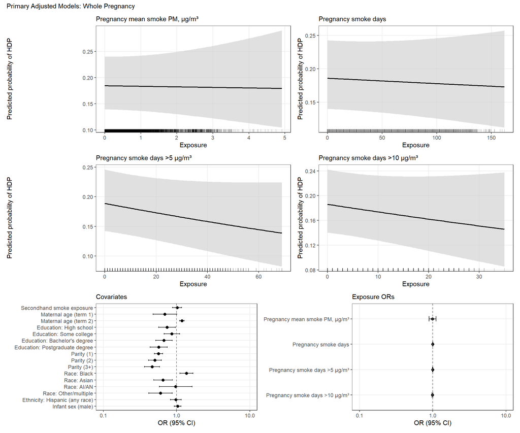

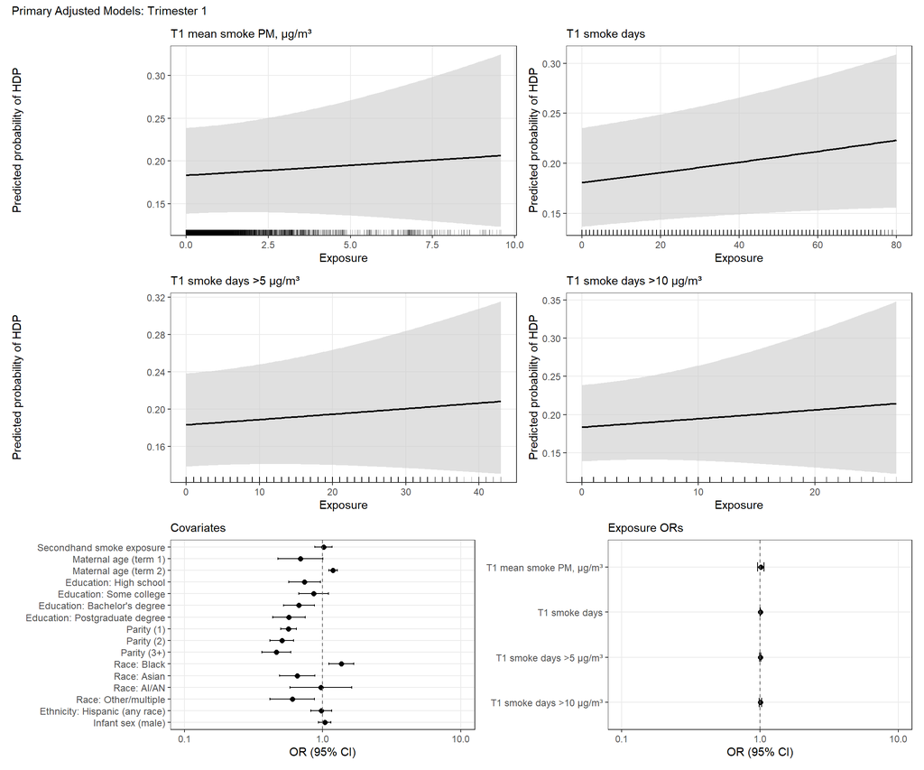

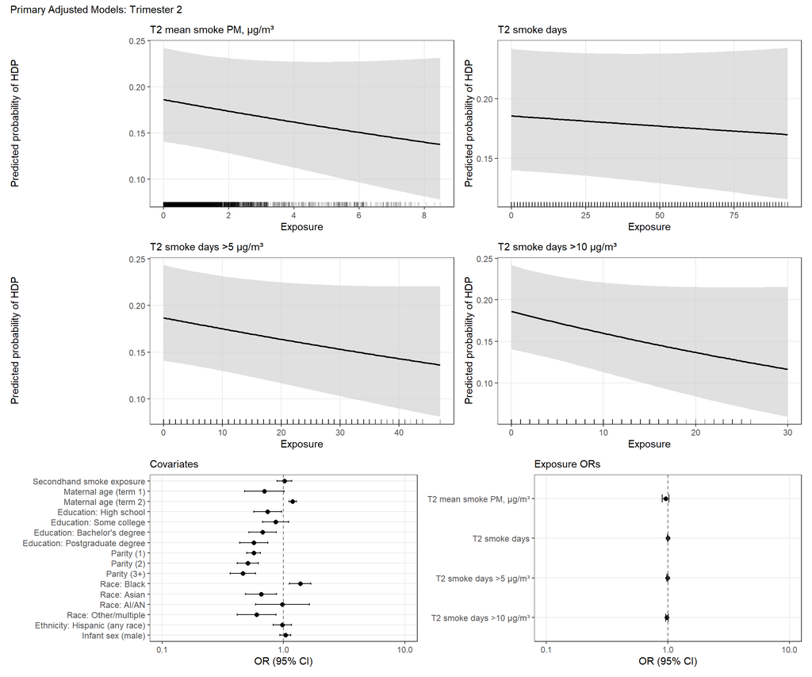

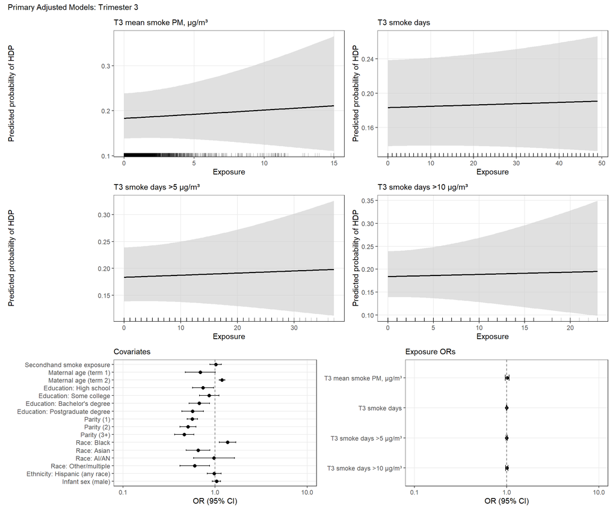

## 2.2 Fully Adjusted

From AP: “Extended models will be additionally adjusted for covariates selected based on availability of harmonized variables across cohorts, including household size-adjusted income (or neighborhood deprivation index), maternal pre-pregnancy BMI, history of chronic hypertension, history of pre-eclampsia, pre-pregnancy diabetes, prenatal smoking.”

- Model: Same parameters as primary adjusted model for exposure, outcome, cohort random intercept, handling missing data, and model optimization.
- Covariates: Maternal age (splined), secular trend (year splines), census macro region, tobacco use, alcohol consumption, tract-level poverty, pre-pregnancy BMI, birthing parent educational attainment, parity, race/ethnicity, infant sex

Extended Adjusted Model: preg_smoke_days

| Term | OR | 95% CI Low | 95% CI High | P-value |
| --- | --- | --- | --- | --- |
| Intercept | 0.120 | 0.066 | 0.216 | 0.0000 |
| preg_smoke_days (exposure) | 0.995 | 0.991 | 0.998 | 0.0041 |
| Secondhand smoke exposure | 0.939 | 0.807 | 1.093 | 0.4155 |
| Maternal age (term 1) | 0.635 | 0.434 | 0.930 | 0.0196 |
| Maternal age (term 2) | 1.153 | 1.074 | 1.239 | 0.0001 |
| Year (term 1) | 1.215 | 0.795 | 1.857 | 0.3687 |
| Year (term 2) | 0.564 | 0.332 | 0.956 | 0.0333 |
| Year (term 3) | 0.973 | 0.604 | 1.569 | 0.9114 |
| Smoking | 1.230 | 0.978 | 1.547 | 0.0765 |
| Alcohol consumption | 0.925 | 0.780 | 1.096 | 0.3652 |
| Spring conception | 1.033 | 0.877 | 1.216 | 0.6990 |
| Summer conception | 0.979 | 0.845 | 1.134 | 0.7752 |
| Winter conception | 1.046 | 0.890 | 1.229 | 0.5878 |
| Midwest | 1.064 | 0.912 | 1.242 | 0.4311 |
| South | 1.252 | 1.068 | 1.468 | 0.0056 |
| West | 1.055 | 0.905 | 1.228 | 0.4940 |
| Tract-level poverty | 0.997 | 0.992 | 1.001 | 0.1339 |
| BMI: Normal weight | 1.208 | 0.738 | 1.978 | 0.4513 |
| BMI: Overweight | 1.954 | 1.192 | 3.205 | 0.0081 |
| BMI: Obese | 3.276 | 2.007 | 5.346 | 0.0000 |
| Education: High school | 0.749 | 0.573 | 0.978 | 0.0337 |
| Education: Some college | 0.894 | 0.697 | 1.147 | 0.3795 |
| Education: Bachelor’s degree | 0.785 | 0.604 | 1.021 | 0.0713 |
| Education: Postgraduate degree | 0.710 | 0.539 | 0.935 | 0.0148 |
| Parity (1) | 0.551 | 0.482 | 0.628 | 0.0000 |
| Parity (2) | 0.494 | 0.404 | 0.605 | 0.0000 |
| Parity (3+) | 0.426 | 0.335 | 0.542 | 0.0000 |
| Race: Black | 1.213 | 0.984 | 1.495 | 0.0710 |
| Race: Asian | 0.711 | 0.526 | 0.962 | 0.0270 |
| Race: AI/AN | 0.953 | 0.566 | 1.603 | 0.8555 |
| Race: Other/multiple | 0.589 | 0.406 | 0.856 | 0.0055 |
| Ethnicity: Hispanic (any race) | 0.846 | 0.709 | 1.009 | 0.0629 |
| Infant sex (male) | 1.038 | 0.934 | 1.152 | 0.4921 |

Extended Adjusted Model: T1_smoke_days

| Term | OR | 95% CI Low | 95% CI High | P-value |
| --- | --- | --- | --- | --- |
| Intercept | 0.111 | 0.062 | 0.199 | 0.0000 |
| T1_smoke_days (exposure) | 1.004 | 0.999 | 1.009 | 0.0943 |
| Secondhand smoke exposure | 0.935 | 0.804 | 1.088 | 0.3857 |
| Maternal age (term 1) | 0.625 | 0.427 | 0.915 | 0.0157 |
| Maternal age (term 2) | 1.159 | 1.079 | 1.244 | 0.0001 |
| Year (term 1) | 1.665 | 1.123 | 2.467 | 0.0111 |
| Year (term 2) | 0.630 | 0.375 | 1.060 | 0.0816 |
| Year (term 3) | 0.655 | 0.425 | 1.011 | 0.0562 |
| Smoking | 1.236 | 0.984 | 1.553 | 0.0687 |
| Alcohol consumption | 0.927 | 0.782 | 1.098 | 0.3790 |
| Spring conception | 0.909 | 0.776 | 1.064 | 0.2347 |
| Summer conception | 0.886 | 0.744 | 1.053 | 0.1701 |
| Winter conception | 0.964 | 0.830 | 1.120 | 0.6331 |
| Midwest | 1.056 | 0.904 | 1.232 | 0.4931 |
| South | 1.252 | 1.068 | 1.468 | 0.0056 |
| West | 1.055 | 0.906 | 1.229 | 0.4892 |
| Tract-level poverty | 0.996 | 0.992 | 1.001 | 0.1263 |
| BMI: Normal weight | 1.205 | 0.736 | 1.974 | 0.4575 |
| BMI: Overweight | 1.948 | 1.187 | 3.196 | 0.0085 |
| BMI: Obese | 3.275 | 2.006 | 5.347 | 0.0000 |
| Education: High school | 0.745 | 0.571 | 0.973 | 0.0306 |
| Education: Some college | 0.894 | 0.696 | 1.146 | 0.3759 |
| Education: Bachelor’s degree | 0.781 | 0.601 | 1.016 | 0.0659 |
| Education: Postgraduate degree | 0.709 | 0.538 | 0.934 | 0.0144 |
| Parity (1) | 0.547 | 0.479 | 0.624 | 0.0000 |
| Parity (2) | 0.491 | 0.401 | 0.601 | 0.0000 |
| Parity (3+) | 0.425 | 0.335 | 0.540 | 0.0000 |
| Race: Black | 1.226 | 0.995 | 1.512 | 0.0558 |
| Race: Asian | 0.723 | 0.535 | 0.978 | 0.0354 |
| Race: AI/AN | 0.956 | 0.568 | 1.608 | 0.8659 |
| Race: Other/multiple | 0.601 | 0.414 | 0.873 | 0.0076 |
| Ethnicity: Hispanic (any race) | 0.863 | 0.724 | 1.030 | 0.1018 |
| Infant sex (male) | 1.034 | 0.931 | 1.149 | 0.5299 |

Extended Adjusted Model: T2_smoke_days

| Term | OR | 95% CI Low | 95% CI High | P-value |
| --- | --- | --- | --- | --- |
| Intercept | 0.111 | 0.062 | 0.200 | 0.0000 |
| T2_smoke_days (exposure) | 0.996 | 0.991 | 1.000 | 0.0596 |
| Secondhand smoke exposure | 0.937 | 0.805 | 1.090 | 0.3980 |
| Maternal age (term 1) | 0.631 | 0.431 | 0.924 | 0.0179 |
| Maternal age (term 2) | 1.155 | 1.076 | 1.241 | 0.0001 |
| Year (term 1) | 1.424 | 0.957 | 2.121 | 0.0816 |
| Year (term 2) | 0.597 | 0.354 | 1.008 | 0.0534 |
| Year (term 3) | 0.793 | 0.511 | 1.230 | 0.2998 |
| Smoking | 1.233 | 0.981 | 1.551 | 0.0724 |
| Alcohol consumption | 0.925 | 0.780 | 1.096 | 0.3674 |
| Spring conception | 1.039 | 0.867 | 1.244 | 0.6798 |
| Summer conception | 0.957 | 0.827 | 1.108 | 0.5577 |
| Winter conception | 1.017 | 0.864 | 1.196 | 0.8404 |
| Midwest | 1.059 | 0.907 | 1.236 | 0.4681 |
| South | 1.252 | 1.068 | 1.467 | 0.0056 |
| West | 1.055 | 0.906 | 1.229 | 0.4906 |
| Tract-level poverty | 0.996 | 0.992 | 1.001 | 0.1308 |
| BMI: Normal weight | 1.205 | 0.736 | 1.975 | 0.4568 |
| BMI: Overweight | 1.948 | 1.187 | 3.197 | 0.0085 |
| BMI: Obese | 3.274 | 2.005 | 5.345 | 0.0000 |
| Education: High school | 0.747 | 0.572 | 0.976 | 0.0325 |
| Education: Some college | 0.895 | 0.697 | 1.148 | 0.3818 |
| Education: Bachelor’s degree | 0.783 | 0.602 | 1.018 | 0.0681 |
| Education: Postgraduate degree | 0.709 | 0.538 | 0.934 | 0.0143 |
| Parity (1) | 0.548 | 0.480 | 0.625 | 0.0000 |
| Parity (2) | 0.492 | 0.402 | 0.602 | 0.0000 |
| Parity (3+) | 0.426 | 0.335 | 0.541 | 0.0000 |
| Race: Black | 1.220 | 0.990 | 1.504 | 0.0621 |
| Race: Asian | 0.717 | 0.530 | 0.969 | 0.0304 |
| Race: AI/AN | 0.961 | 0.571 | 1.616 | 0.8803 |
| Race: Other/multiple | 0.595 | 0.409 | 0.864 | 0.0064 |
| Ethnicity: Hispanic (any race) | 0.855 | 0.717 | 1.020 | 0.0812 |
| Infant sex (male) | 1.037 | 0.934 | 1.152 | 0.4962 |

Extended Adjusted Model: T3_smoke_days

| Term | OR | 95% CI Low | 95% CI High | P-value |
| --- | --- | --- | --- | --- |
| Intercept | 0.112 | 0.062 | 0.202 | 0.0000 |
| T3_smoke_days (exposure) | 0.998 | 0.990 | 1.005 | 0.5834 |
| Secondhand smoke exposure | 0.937 | 0.805 | 1.090 | 0.3965 |
| Maternal age (term 1) | 0.628 | 0.429 | 0.920 | 0.0169 |
| Maternal age (term 2) | 1.157 | 1.077 | 1.243 | 0.0001 |
| Year (term 1) | 1.535 | 1.039 | 2.267 | 0.0312 |
| Year (term 2) | 0.614 | 0.365 | 1.033 | 0.0661 |
| Year (term 3) | 0.725 | 0.472 | 1.115 | 0.1430 |
| Smoking | 1.236 | 0.983 | 1.553 | 0.0695 |
| Alcohol consumption | 0.926 | 0.781 | 1.097 | 0.3731 |
| Spring conception | 0.932 | 0.797 | 1.092 | 0.3848 |
| Summer conception | 0.944 | 0.808 | 1.103 | 0.4670 |
| Winter conception | 0.971 | 0.828 | 1.138 | 0.7151 |
| Midwest | 1.059 | 0.907 | 1.236 | 0.4687 |
| South | 1.252 | 1.068 | 1.468 | 0.0056 |
| West | 1.055 | 0.906 | 1.229 | 0.4876 |
| Tract-level poverty | 0.996 | 0.992 | 1.001 | 0.1306 |
| BMI: Normal weight | 1.208 | 0.737 | 1.980 | 0.4517 |
| BMI: Overweight | 1.954 | 1.190 | 3.207 | 0.0082 |
| BMI: Obese | 3.281 | 2.009 | 5.358 | 0.0000 |
| Education: High school | 0.746 | 0.571 | 0.973 | 0.0310 |
| Education: Some college | 0.893 | 0.696 | 1.145 | 0.3727 |
| Education: Bachelor’s degree | 0.781 | 0.601 | 1.016 | 0.0652 |
| Education: Postgraduate degree | 0.708 | 0.538 | 0.933 | 0.0140 |
| Parity (1) | 0.548 | 0.480 | 0.626 | 0.0000 |
| Parity (2) | 0.493 | 0.403 | 0.603 | 0.0000 |
| Parity (3+) | 0.425 | 0.335 | 0.541 | 0.0000 |
| Race: Black | 1.223 | 0.992 | 1.507 | 0.0594 |
| Race: Asian | 0.720 | 0.533 | 0.974 | 0.0329 |
| Race: AI/AN | 0.956 | 0.568 | 1.607 | 0.8645 |
| Race: Other/multiple | 0.598 | 0.412 | 0.869 | 0.0070 |
| Ethnicity: Hispanic (any race) | 0.858 | 0.720 | 1.023 | 0.0887 |
| Infant sex (male) | 1.036 | 0.933 | 1.150 | 0.5115 |

Extended Adjusted Model: preg_smoke_days_over5

| Term | OR | 95% CI Low | 95% CI High | P-value |
| --- | --- | --- | --- | --- |
| Intercept | 0.115 | 0.064 | 0.207 | 0.0000 |
| preg_smoke_days_over5 (exposure) | 0.989 | 0.981 | 0.997 | 0.0092 |
| Secondhand smoke exposure | 0.939 | 0.807 | 1.093 | 0.4146 |
| Maternal age (term 1) | 0.632 | 0.432 | 0.926 | 0.0184 |
| Maternal age (term 2) | 1.156 | 1.076 | 1.241 | 0.0001 |
| Year (term 1) | 1.409 | 0.951 | 2.088 | 0.0876 |
| Year (term 2) | 0.584 | 0.346 | 0.985 | 0.0437 |
| Year (term 3) | 0.803 | 0.521 | 1.239 | 0.3210 |
| Smoking | 1.239 | 0.986 | 1.558 | 0.0664 |
| Alcohol consumption | 0.925 | 0.780 | 1.096 | 0.3650 |
| Spring conception | 0.991 | 0.848 | 1.158 | 0.9056 |
| Summer conception | 0.971 | 0.838 | 1.124 | 0.6906 |
| Winter conception | 0.998 | 0.856 | 1.162 | 0.9756 |
| Midwest | 1.061 | 0.909 | 1.238 | 0.4529 |
| South | 1.250 | 1.066 | 1.465 | 0.0060 |
| West | 1.053 | 0.904 | 1.227 | 0.5057 |
| Tract-level poverty | 0.996 | 0.992 | 1.001 | 0.1280 |
| BMI: Normal weight | 1.214 | 0.742 | 1.988 | 0.4392 |
| BMI: Overweight | 1.963 | 1.196 | 3.220 | 0.0077 |
| BMI: Obese | 3.297 | 2.019 | 5.382 | 0.0000 |
| Education: High school | 0.748 | 0.573 | 0.977 | 0.0330 |
| Education: Some college | 0.894 | 0.697 | 1.147 | 0.3768 |
| Education: Bachelor’s degree | 0.783 | 0.602 | 1.018 | 0.0678 |
| Education: Postgraduate degree | 0.710 | 0.539 | 0.935 | 0.0148 |
| Parity (1) | 0.550 | 0.482 | 0.628 | 0.0000 |
| Parity (2) | 0.495 | 0.404 | 0.605 | 0.0000 |
| Parity (3+) | 0.427 | 0.336 | 0.543 | 0.0000 |
| Race: Black | 1.227 | 0.995 | 1.512 | 0.0556 |
| Race: Asian | 0.718 | 0.531 | 0.970 | 0.0309 |
| Race: AI/AN | 0.988 | 0.587 | 1.663 | 0.9642 |
| Race: Other/multiple | 0.596 | 0.410 | 0.866 | 0.0066 |
| Ethnicity: Hispanic (any race) | 0.854 | 0.716 | 1.019 | 0.0803 |
| Infant sex (male) | 1.035 | 0.932 | 1.150 | 0.5166 |

Extended Adjusted Model: T1_smoke_days_over5

| Term | OR | 95% CI Low | 95% CI High | P-value |
| --- | --- | --- | --- | --- |
| Intercept | 0.111 | 0.062 | 0.199 | 0.0000 |
| T1_smoke_days_over5 (exposure) | 1.003 | 0.991 | 1.015 | 0.6503 |
| Secondhand smoke exposure | 0.936 | 0.804 | 1.089 | 0.3919 |
| Maternal age (term 1) | 0.628 | 0.429 | 0.920 | 0.0168 |
| Maternal age (term 2) | 1.157 | 1.077 | 1.243 | 0.0001 |
| Year (term 1) | 1.568 | 1.064 | 2.310 | 0.0228 |
| Year (term 2) | 0.620 | 0.369 | 1.044 | 0.0720 |
| Year (term 3) | 0.706 | 0.461 | 1.080 | 0.1080 |
| Smoking | 1.236 | 0.983 | 1.553 | 0.0692 |
| Alcohol consumption | 0.926 | 0.781 | 1.097 | 0.3707 |
| Spring conception | 0.938 | 0.804 | 1.094 | 0.4145 |
| Summer conception | 0.945 | 0.806 | 1.107 | 0.4808 |
| Winter conception | 0.958 | 0.825 | 1.112 | 0.5708 |
| Midwest | 1.058 | 0.906 | 1.235 | 0.4748 |
| South | 1.252 | 1.068 | 1.468 | 0.0056 |
| West | 1.056 | 0.906 | 1.229 | 0.4870 |
| Tract-level poverty | 0.996 | 0.992 | 1.001 | 0.1301 |
| BMI: Normal weight | 1.208 | 0.737 | 1.980 | 0.4528 |
| BMI: Overweight | 1.953 | 1.189 | 3.207 | 0.0083 |
| BMI: Obese | 3.281 | 2.008 | 5.359 | 0.0000 |
| Education: High school | 0.746 | 0.571 | 0.974 | 0.0311 |
| Education: Some college | 0.893 | 0.696 | 1.146 | 0.3746 |
| Education: Bachelor’s degree | 0.781 | 0.601 | 1.016 | 0.0658 |
| Education: Postgraduate degree | 0.708 | 0.538 | 0.933 | 0.0141 |
| Parity (1) | 0.547 | 0.479 | 0.625 | 0.0000 |
| Parity (2) | 0.492 | 0.402 | 0.602 | 0.0000 |
| Parity (3+) | 0.425 | 0.335 | 0.540 | 0.0000 |
| Race: Black | 1.223 | 0.992 | 1.508 | 0.0590 |
| Race: Asian | 0.721 | 0.533 | 0.974 | 0.0332 |
| Race: AI/AN | 0.956 | 0.568 | 1.607 | 0.8640 |
| Race: Other/multiple | 0.599 | 0.412 | 0.870 | 0.0071 |
| Ethnicity: Hispanic (any race) | 0.860 | 0.721 | 1.025 | 0.0925 |
| Infant sex (male) | 1.036 | 0.933 | 1.151 | 0.5083 |

Extended Adjusted Model: T2_smoke_days_over5

| Term | OR | 95% CI Low | 95% CI High | P-value |
| --- | --- | --- | --- | --- |
| Intercept | 0.111 | 0.062 | 0.200 | 0.0000 |
| T2_smoke_days_over5 (exposure) | 0.986 | 0.974 | 0.999 | 0.0287 |
| Secondhand smoke exposure | 0.937 | 0.805 | 1.091 | 0.4028 |
| Maternal age (term 1) | 0.630 | 0.431 | 0.923 | 0.0177 |
| Maternal age (term 2) | 1.156 | 1.076 | 1.241 | 0.0001 |
| Year (term 1) | 1.474 | 0.999 | 2.176 | 0.0508 |
| Year (term 2) | 0.599 | 0.355 | 1.008 | 0.0538 |
| Year (term 3) | 0.758 | 0.495 | 1.163 | 0.2051 |
| Smoking | 1.241 | 0.987 | 1.561 | 0.0642 |
| Alcohol consumption | 0.925 | 0.780 | 1.096 | 0.3669 |
| Spring conception | 1.023 | 0.866 | 1.208 | 0.7919 |
| Summer conception | 0.960 | 0.829 | 1.111 | 0.5824 |
| Winter conception | 1.004 | 0.860 | 1.173 | 0.9579 |
| Midwest | 1.057 | 0.906 | 1.234 | 0.4827 |
| South | 1.249 | 1.066 | 1.464 | 0.0061 |
| West | 1.054 | 0.905 | 1.228 | 0.4981 |
| Tract-level poverty | 0.996 | 0.992 | 1.001 | 0.1264 |
| BMI: Normal weight | 1.209 | 0.738 | 1.981 | 0.4503 |
| BMI: Overweight | 1.951 | 1.188 | 3.204 | 0.0084 |
| BMI: Obese | 3.282 | 2.009 | 5.360 | 0.0000 |
| Education: High school | 0.747 | 0.572 | 0.976 | 0.0323 |
| Education: Some college | 0.894 | 0.697 | 1.147 | 0.3779 |
| Education: Bachelor’s degree | 0.783 | 0.602 | 1.018 | 0.0680 |
| Education: Postgraduate degree | 0.710 | 0.539 | 0.935 | 0.0147 |
| Parity (1) | 0.548 | 0.480 | 0.626 | 0.0000 |
| Parity (2) | 0.492 | 0.402 | 0.602 | 0.0000 |
| Parity (3+) | 0.427 | 0.336 | 0.543 | 0.0000 |
| Race: Black | 1.227 | 0.995 | 1.513 | 0.0552 |
| Race: Asian | 0.719 | 0.532 | 0.973 | 0.0323 |
| Race: AI/AN | 0.979 | 0.582 | 1.646 | 0.9351 |
| Race: Other/multiple | 0.596 | 0.411 | 0.866 | 0.0067 |
| Ethnicity: Hispanic (any race) | 0.858 | 0.720 | 1.024 | 0.0894 |
| Infant sex (male) | 1.037 | 0.933 | 1.151 | 0.5028 |

Extended Adjusted Model: T3_smoke_days_over5

| Term | OR | 95% CI Low | 95% CI High | P-value |
| --- | --- | --- | --- | --- |
| Intercept | 0.111 | 0.062 | 0.200 | 0.0000 |
| T3_smoke_days_over5 (exposure) | 0.998 | 0.981 | 1.017 | 0.8684 |
| Secondhand smoke exposure | 0.936 | 0.805 | 1.089 | 0.3941 |
| Maternal age (term 1) | 0.629 | 0.430 | 0.920 | 0.0170 |
| Maternal age (term 2) | 1.157 | 1.077 | 1.242 | 0.0001 |
| Year (term 1) | 1.553 | 1.054 | 2.289 | 0.0259 |
| Year (term 2) | 0.617 | 0.367 | 1.038 | 0.0689 |
| Year (term 3) | 0.714 | 0.466 | 1.092 | 0.1204 |
| Smoking | 1.236 | 0.983 | 1.553 | 0.0693 |
| Alcohol consumption | 0.925 | 0.781 | 1.097 | 0.3700 |
| Spring conception | 0.942 | 0.808 | 1.098 | 0.4453 |
| Summer conception | 0.955 | 0.822 | 1.110 | 0.5495 |
| Winter conception | 0.959 | 0.823 | 1.118 | 0.5909 |
| Midwest | 1.059 | 0.907 | 1.236 | 0.4695 |
| South | 1.252 | 1.068 | 1.468 | 0.0056 |
| West | 1.055 | 0.906 | 1.229 | 0.4878 |
| Tract-level poverty | 0.996 | 0.992 | 1.001 | 0.1306 |
| BMI: Normal weight | 1.209 | 0.738 | 1.981 | 0.4506 |
| BMI: Overweight | 1.955 | 1.191 | 3.210 | 0.0082 |
| BMI: Obese | 3.284 | 2.010 | 5.364 | 0.0000 |
| Education: High school | 0.746 | 0.571 | 0.974 | 0.0311 |
| Education: Some college | 0.893 | 0.696 | 1.146 | 0.3741 |
| Education: Bachelor’s degree | 0.781 | 0.601 | 1.016 | 0.0653 |
| Education: Postgraduate degree | 0.708 | 0.538 | 0.933 | 0.0141 |
| Parity (1) | 0.548 | 0.480 | 0.625 | 0.0000 |
| Parity (2) | 0.492 | 0.403 | 0.602 | 0.0000 |
| Parity (3+) | 0.425 | 0.335 | 0.541 | 0.0000 |
| Race: Black | 1.223 | 0.992 | 1.507 | 0.0593 |
| Race: Asian | 0.720 | 0.533 | 0.974 | 0.0328 |
| Race: AI/AN | 0.958 | 0.570 | 1.611 | 0.8725 |
| Race: Other/multiple | 0.598 | 0.412 | 0.869 | 0.0070 |
| Ethnicity: Hispanic (any race) | 0.859 | 0.720 | 1.024 | 0.0902 |
| Infant sex (male) | 1.036 | 0.933 | 1.151 | 0.5082 |

Extended Adjusted Model: preg_smoke_days_over10

| Term | OR | 95% CI Low | 95% CI High | P-value |
| --- | --- | --- | --- | --- |
| Intercept | 0.112 | 0.062 | 0.201 | 0.0000 |
| preg_smoke_days_over10 (exposure) | 0.986 | 0.971 | 1.001 | 0.0640 |
| Secondhand smoke exposure | 0.938 | 0.806 | 1.092 | 0.4096 |
| Maternal age (term 1) | 0.631 | 0.431 | 0.923 | 0.0177 |
| Maternal age (term 2) | 1.156 | 1.076 | 1.242 | 0.0001 |
| Year (term 1) | 1.553 | 1.056 | 2.283 | 0.0253 |
| Year (term 2) | 0.593 | 0.352 | 0.999 | 0.0495 |
| Year (term 3) | 0.720 | 0.472 | 1.099 | 0.1279 |
| Smoking | 1.240 | 0.987 | 1.559 | 0.0649 |
| Alcohol consumption | 0.923 | 0.779 | 1.094 | 0.3546 |
| Spring conception | 0.965 | 0.828 | 1.125 | 0.6514 |
| Summer conception | 0.966 | 0.834 | 1.118 | 0.6392 |
| Winter conception | 0.975 | 0.839 | 1.134 | 0.7445 |
| Midwest | 1.058 | 0.907 | 1.235 | 0.4734 |
| South | 1.249 | 1.065 | 1.464 | 0.0061 |
| West | 1.054 | 0.905 | 1.228 | 0.4951 |
| Tract-level poverty | 0.996 | 0.992 | 1.001 | 0.1323 |
| BMI: Normal weight | 1.215 | 0.742 | 1.990 | 0.4384 |
| BMI: Overweight | 1.962 | 1.196 | 3.221 | 0.0078 |
| BMI: Obese | 3.298 | 2.019 | 5.386 | 0.0000 |
| Education: High school | 0.748 | 0.573 | 0.976 | 0.0326 |
| Education: Some college | 0.896 | 0.698 | 1.149 | 0.3855 |
| Education: Bachelor’s degree | 0.783 | 0.602 | 1.019 | 0.0684 |
| Education: Postgraduate degree | 0.711 | 0.540 | 0.936 | 0.0152 |
| Parity (1) | 0.549 | 0.481 | 0.627 | 0.0000 |
| Parity (2) | 0.494 | 0.404 | 0.604 | 0.0000 |
| Parity (3+) | 0.426 | 0.335 | 0.542 | 0.0000 |
| Race: Black | 1.225 | 0.994 | 1.511 | 0.0568 |
| Race: Asian | 0.719 | 0.532 | 0.971 | 0.0316 |
| Race: AI/AN | 0.987 | 0.586 | 1.662 | 0.9614 |
| Race: Other/multiple | 0.599 | 0.412 | 0.870 | 0.0072 |
| Ethnicity: Hispanic (any race) | 0.858 | 0.719 | 1.023 | 0.0875 |
| Infant sex (male) | 1.035 | 0.932 | 1.150 | 0.5157 |

Extended Adjusted Model: T1_smoke_days_over10

| Term | OR | 95% CI Low | 95% CI High | P-value |
| --- | --- | --- | --- | --- |
| Intercept | 0.111 | 0.062 | 0.199 | 0.0000 |
| T1_smoke_days_over10 (exposure) | 1.005 | 0.982 | 1.029 | 0.6854 |
| Secondhand smoke exposure | 0.936 | 0.804 | 1.089 | 0.3923 |
| Maternal age (term 1) | 0.629 | 0.430 | 0.921 | 0.0171 |
| Maternal age (term 2) | 1.157 | 1.077 | 1.243 | 0.0001 |
| Year (term 1) | 1.556 | 1.058 | 2.290 | 0.0248 |
| Year (term 2) | 0.621 | 0.369 | 1.045 | 0.0726 |
| Year (term 3) | 0.711 | 0.466 | 1.087 | 0.1153 |
| Smoking | 1.236 | 0.983 | 1.553 | 0.0694 |
| Alcohol consumption | 0.926 | 0.781 | 1.097 | 0.3711 |
| Spring conception | 0.941 | 0.808 | 1.096 | 0.4335 |
| Summer conception | 0.950 | 0.815 | 1.106 | 0.5062 |
| Winter conception | 0.957 | 0.824 | 1.111 | 0.5616 |
| Midwest | 1.058 | 0.907 | 1.235 | 0.4718 |
| South | 1.252 | 1.068 | 1.468 | 0.0056 |
| West | 1.055 | 0.906 | 1.229 | 0.4878 |
| Tract-level poverty | 0.996 | 0.992 | 1.001 | 0.1299 |
| BMI: Normal weight | 1.208 | 0.737 | 1.980 | 0.4523 |
| BMI: Overweight | 1.954 | 1.190 | 3.208 | 0.0083 |
| BMI: Obese | 3.282 | 2.009 | 5.361 | 0.0000 |
| Education: High school | 0.746 | 0.571 | 0.974 | 0.0311 |
| Education: Some college | 0.893 | 0.696 | 1.146 | 0.3730 |
| Education: Bachelor’s degree | 0.781 | 0.601 | 1.016 | 0.0654 |
| Education: Postgraduate degree | 0.708 | 0.538 | 0.932 | 0.0140 |
| Parity (1) | 0.547 | 0.479 | 0.625 | 0.0000 |
| Parity (2) | 0.492 | 0.402 | 0.602 | 0.0000 |
| Parity (3+) | 0.425 | 0.335 | 0.540 | 0.0000 |
| Race: Black | 1.223 | 0.992 | 1.507 | 0.0595 |
| Race: Asian | 0.720 | 0.533 | 0.974 | 0.0329 |
| Race: AI/AN | 0.956 | 0.568 | 1.607 | 0.8640 |
| Race: Other/multiple | 0.598 | 0.412 | 0.869 | 0.0070 |
| Ethnicity: Hispanic (any race) | 0.859 | 0.721 | 1.025 | 0.0917 |
| Infant sex (male) | 1.036 | 0.933 | 1.151 | 0.5067 |

Extended Adjusted Model: T2_smoke_days_over10

| Term | OR | 95% CI Low | 95% CI High | P-value |
| --- | --- | --- | --- | --- |
| Intercept | 0.110 | 0.061 | 0.199 | 0.0000 |
| T2_smoke_days_over10 (exposure) | 0.975 | 0.952 | 0.999 | 0.0381 |
| Secondhand smoke exposure | 0.937 | 0.806 | 1.091 | 0.4039 |
| Maternal age (term 1) | 0.630 | 0.431 | 0.923 | 0.0176 |
| Maternal age (term 2) | 1.156 | 1.076 | 1.241 | 0.0001 |
| Year (term 1) | 1.551 | 1.055 | 2.281 | 0.0257 |
| Year (term 2) | 0.598 | 0.355 | 1.007 | 0.0530 |
| Year (term 3) | 0.718 | 0.470 | 1.096 | 0.1248 |
| Smoking | 1.244 | 0.989 | 1.563 | 0.0618 |
| Alcohol consumption | 0.924 | 0.780 | 1.095 | 0.3629 |
| Spring conception | 0.994 | 0.848 | 1.164 | 0.9378 |
| Summer conception | 0.959 | 0.828 | 1.110 | 0.5748 |
| Winter conception | 0.983 | 0.845 | 1.144 | 0.8240 |
| Midwest | 1.056 | 0.905 | 1.232 | 0.4914 |
| South | 1.248 | 1.065 | 1.463 | 0.0063 |
| West | 1.054 | 0.905 | 1.227 | 0.4995 |
| Tract-level poverty | 0.996 | 0.992 | 1.001 | 0.1307 |
| BMI: Normal weight | 1.213 | 0.740 | 1.987 | 0.4435 |
| BMI: Overweight | 1.956 | 1.191 | 3.211 | 0.0082 |
| BMI: Obese | 3.291 | 2.015 | 5.377 | 0.0000 |
| Education: High school | 0.746 | 0.571 | 0.974 | 0.0314 |
| Education: Some college | 0.894 | 0.697 | 1.147 | 0.3778 |
| Education: Bachelor’s degree | 0.782 | 0.602 | 1.018 | 0.0674 |
| Education: Postgraduate degree | 0.710 | 0.539 | 0.934 | 0.0146 |
| Parity (1) | 0.548 | 0.480 | 0.626 | 0.0000 |
| Parity (2) | 0.492 | 0.403 | 0.602 | 0.0000 |
| Parity (3+) | 0.426 | 0.335 | 0.542 | 0.0000 |
| Race: Black | 1.225 | 0.994 | 1.510 | 0.0575 |
| Race: Asian | 0.720 | 0.532 | 0.973 | 0.0325 |
| Race: AI/AN | 0.983 | 0.584 | 1.653 | 0.9475 |
| Race: Other/multiple | 0.597 | 0.411 | 0.868 | 0.0069 |
| Ethnicity: Hispanic (any race) | 0.859 | 0.720 | 1.024 | 0.0901 |
| Infant sex (male) | 1.036 | 0.933 | 1.151 | 0.5060 |

Extended Adjusted Model: T3_smoke_days_over10

| Term | OR | 95% CI Low | 95% CI High | P-value |
| --- | --- | --- | --- | --- |
| Intercept | 0.111 | 0.062 | 0.199 | 0.0000 |
| T3_smoke_days_over10 (exposure) | 0.998 | 0.965 | 1.031 | 0.8928 |
| Secondhand smoke exposure | 0.936 | 0.804 | 1.089 | 0.3939 |
| Maternal age (term 1) | 0.629 | 0.430 | 0.921 | 0.0171 |
| Maternal age (term 2) | 1.157 | 1.077 | 1.242 | 0.0001 |
| Year (term 1) | 1.557 | 1.058 | 2.291 | 0.0246 |
| Year (term 2) | 0.617 | 0.367 | 1.039 | 0.0692 |
| Year (term 3) | 0.712 | 0.466 | 1.087 | 0.1157 |
| Smoking | 1.236 | 0.983 | 1.553 | 0.0692 |
| Alcohol consumption | 0.925 | 0.781 | 1.097 | 0.3693 |
| Spring conception | 0.943 | 0.810 | 1.098 | 0.4504 |
| Summer conception | 0.957 | 0.826 | 1.109 | 0.5567 |
| Winter conception | 0.958 | 0.823 | 1.114 | 0.5769 |
| Midwest | 1.059 | 0.907 | 1.236 | 0.4697 |
| South | 1.252 | 1.068 | 1.468 | 0.0056 |
| West | 1.055 | 0.906 | 1.229 | 0.4876 |
| Tract-level poverty | 0.996 | 0.992 | 1.001 | 0.1305 |
| BMI: Normal weight | 1.209 | 0.738 | 1.981 | 0.4505 |
| BMI: Overweight | 1.955 | 1.191 | 3.210 | 0.0082 |
| BMI: Obese | 3.284 | 2.010 | 5.364 | 0.0000 |
| Education: High school | 0.746 | 0.571 | 0.974 | 0.0311 |
| Education: Some college | 0.893 | 0.696 | 1.146 | 0.3742 |
| Education: Bachelor’s degree | 0.781 | 0.601 | 1.016 | 0.0654 |
| Education: Postgraduate degree | 0.708 | 0.538 | 0.933 | 0.0141 |
| Parity (1) | 0.548 | 0.480 | 0.625 | 0.0000 |
| Parity (2) | 0.492 | 0.403 | 0.602 | 0.0000 |
| Parity (3+) | 0.425 | 0.335 | 0.541 | 0.0000 |
| Race: Black | 1.223 | 0.992 | 1.507 | 0.0593 |
| Race: Asian | 0.720 | 0.533 | 0.973 | 0.0328 |
| Race: AI/AN | 0.959 | 0.570 | 1.612 | 0.8730 |
| Race: Other/multiple | 0.598 | 0.412 | 0.869 | 0.0070 |
| Ethnicity: Hispanic (any race) | 0.859 | 0.720 | 1.024 | 0.0906 |
| Infant sex (male) | 1.036 | 0.933 | 1.151 | 0.5070 |

Extended Adjusted Model: preg_smokePM_mean

| Term | OR | 95% CI Low | 95% CI High | P-value |
| --- | --- | --- | --- | --- |
| Intercept | 0.113 | 0.063 | 0.203 | 0.0000 |
| preg_smokePM_mean (exposure) | 0.917 | 0.807 | 1.043 | 0.1868 |
| Secondhand smoke exposure | 0.937 | 0.805 | 1.090 | 0.4001 |
| Maternal age (term 1) | 0.630 | 0.430 | 0.922 | 0.0174 |
| Maternal age (term 2) | 1.156 | 1.077 | 1.242 | 0.0001 |
| Year (term 1) | 1.486 | 1.004 | 2.201 | 0.0478 |
| Year (term 2) | 0.598 | 0.355 | 1.009 | 0.0539 |
| Year (term 3) | 0.755 | 0.490 | 1.165 | 0.2042 |
| Smoking | 1.237 | 0.984 | 1.555 | 0.0680 |
| Alcohol consumption | 0.925 | 0.780 | 1.096 | 0.3648 |
| Spring conception | 0.964 | 0.826 | 1.126 | 0.6442 |
| Summer conception | 0.963 | 0.831 | 1.115 | 0.6131 |
| Winter conception | 0.975 | 0.838 | 1.136 | 0.7496 |
| Midwest | 1.060 | 0.908 | 1.237 | 0.4613 |
| South | 1.251 | 1.067 | 1.467 | 0.0057 |
| West | 1.055 | 0.906 | 1.229 | 0.4914 |
| Tract-level poverty | 0.996 | 0.992 | 1.001 | 0.1306 |
| BMI: Normal weight | 1.211 | 0.739 | 1.983 | 0.4468 |
| BMI: Overweight | 1.957 | 1.192 | 3.212 | 0.0081 |
| BMI: Obese | 3.288 | 2.013 | 5.369 | 0.0000 |
| Education: High school | 0.747 | 0.572 | 0.975 | 0.0319 |
| Education: Some college | 0.894 | 0.697 | 1.147 | 0.3768 |
| Education: Bachelor’s degree | 0.782 | 0.601 | 1.017 | 0.0665 |
| Education: Postgraduate degree | 0.710 | 0.539 | 0.934 | 0.0145 |
| Parity (1) | 0.549 | 0.481 | 0.627 | 0.0000 |
| Parity (2) | 0.494 | 0.404 | 0.604 | 0.0000 |
| Parity (3+) | 0.426 | 0.335 | 0.542 | 0.0000 |
| Race: Black | 1.223 | 0.992 | 1.508 | 0.0589 |
| Race: Asian | 0.718 | 0.531 | 0.971 | 0.0314 |
| Race: AI/AN | 0.972 | 0.578 | 1.635 | 0.9141 |
| Race: Other/multiple | 0.597 | 0.411 | 0.867 | 0.0067 |
| Ethnicity: Hispanic (any race) | 0.856 | 0.718 | 1.021 | 0.0839 |
| Infant sex (male) | 1.036 | 0.933 | 1.151 | 0.5081 |

Extended Adjusted Model: T1_smokePM_mean

| Term | OR | 95% CI Low | 95% CI High | P-value |
| --- | --- | --- | --- | --- |
| Intercept | 0.111 | 0.062 | 0.199 | 0.0000 |
| T1_smokePM_mean (exposure) | 1.006 | 0.945 | 1.070 | 0.8598 |
| Secondhand smoke exposure | 0.936 | 0.804 | 1.089 | 0.3924 |
| Maternal age (term 1) | 0.629 | 0.429 | 0.920 | 0.0170 |
| Maternal age (term 2) | 1.157 | 1.077 | 1.243 | 0.0001 |
| Year (term 1) | 1.562 | 1.060 | 2.300 | 0.0241 |
| Year (term 2) | 0.619 | 0.368 | 1.042 | 0.0711 |
| Year (term 3) | 0.709 | 0.463 | 1.085 | 0.1132 |
| Smoking | 1.236 | 0.983 | 1.553 | 0.0693 |
| Alcohol consumption | 0.925 | 0.781 | 1.097 | 0.3704 |
| Spring conception | 0.942 | 0.808 | 1.098 | 0.4444 |
| Summer conception | 0.953 | 0.815 | 1.115 | 0.5476 |
| Winter conception | 0.957 | 0.824 | 1.111 | 0.5614 |
| Midwest | 1.058 | 0.907 | 1.235 | 0.4721 |
| South | 1.252 | 1.068 | 1.468 | 0.0056 |
| West | 1.055 | 0.906 | 1.229 | 0.4878 |
| Tract-level poverty | 0.996 | 0.992 | 1.001 | 0.1303 |
| BMI: Normal weight | 1.208 | 0.737 | 1.981 | 0.4514 |
| BMI: Overweight | 1.954 | 1.190 | 3.209 | 0.0082 |
| BMI: Obese | 3.283 | 2.010 | 5.363 | 0.0000 |
| Education: High school | 0.746 | 0.571 | 0.974 | 0.0311 |
| Education: Some college | 0.893 | 0.696 | 1.146 | 0.3744 |
| Education: Bachelor’s degree | 0.781 | 0.601 | 1.016 | 0.0655 |
| Education: Postgraduate degree | 0.708 | 0.538 | 0.933 | 0.0141 |
| Parity (1) | 0.547 | 0.479 | 0.625 | 0.0000 |
| Parity (2) | 0.492 | 0.402 | 0.602 | 0.0000 |
| Parity (3+) | 0.425 | 0.335 | 0.541 | 0.0000 |
| Race: Black | 1.223 | 0.992 | 1.507 | 0.0593 |
| Race: Asian | 0.720 | 0.533 | 0.974 | 0.0329 |
| Race: AI/AN | 0.957 | 0.569 | 1.609 | 0.8684 |
| Race: Other/multiple | 0.598 | 0.412 | 0.869 | 0.0070 |
| Ethnicity: Hispanic (any race) | 0.859 | 0.720 | 1.025 | 0.0914 |
| Infant sex (male) | 1.036 | 0.933 | 1.151 | 0.5070 |

Extended Adjusted Model: T2_smokePM_mean

| Term | OR | 95% CI Low | 95% CI High | P-value |
| --- | --- | --- | --- | --- |
| Intercept | 0.111 | 0.062 | 0.199 | 0.0000 |
| T2_smokePM_mean (exposure) | 0.924 | 0.855 | 0.998 | 0.0445 |
| Secondhand smoke exposure | 0.937 | 0.805 | 1.090 | 0.3979 |
| Maternal age (term 1) | 0.630 | 0.430 | 0.922 | 0.0175 |
| Maternal age (term 2) | 1.156 | 1.076 | 1.241 | 0.0001 |
| Year (term 1) | 1.485 | 1.006 | 2.191 | 0.0464 |
| Year (term 2) | 0.598 | 0.355 | 1.007 | 0.0532 |
| Year (term 3) | 0.754 | 0.492 | 1.157 | 0.1963 |
| Smoking | 1.240 | 0.986 | 1.559 | 0.0654 |
| Alcohol consumption | 0.925 | 0.780 | 1.096 | 0.3662 |
| Spring conception | 1.011 | 0.857 | 1.192 | 0.8978 |
| Summer conception | 0.958 | 0.828 | 1.110 | 0.5697 |
| Winter conception | 0.997 | 0.854 | 1.164 | 0.9746 |
| Midwest | 1.057 | 0.905 | 1.233 | 0.4840 |
| South | 1.250 | 1.066 | 1.465 | 0.0060 |
| West | 1.055 | 0.906 | 1.229 | 0.4911 |
| Tract-level poverty | 0.996 | 0.992 | 1.001 | 0.1285 |
| BMI: Normal weight | 1.209 | 0.738 | 1.982 | 0.4493 |
| BMI: Overweight | 1.951 | 1.189 | 3.203 | 0.0084 |
| BMI: Obese | 3.282 | 2.010 | 5.360 | 0.0000 |
| Education: High school | 0.746 | 0.572 | 0.975 | 0.0318 |
| Education: Some college | 0.894 | 0.697 | 1.147 | 0.3788 |
| Education: Bachelor’s degree | 0.783 | 0.602 | 1.018 | 0.0681 |
| Education: Postgraduate degree | 0.710 | 0.539 | 0.935 | 0.0146 |
| Parity (1) | 0.548 | 0.480 | 0.626 | 0.0000 |
| Parity (2) | 0.493 | 0.403 | 0.603 | 0.0000 |
| Parity (3+) | 0.426 | 0.335 | 0.542 | 0.0000 |
| Race: Black | 1.224 | 0.993 | 1.508 | 0.0586 |
| Race: Asian | 0.719 | 0.532 | 0.971 | 0.0317 |
| Race: AI/AN | 0.974 | 0.579 | 1.639 | 0.9216 |
| Race: Other/multiple | 0.596 | 0.410 | 0.865 | 0.0065 |
| Ethnicity: Hispanic (any race) | 0.857 | 0.719 | 1.022 | 0.0863 |
| Infant sex (male) | 1.037 | 0.933 | 1.151 | 0.5022 |

Extended Adjusted Model: T3_smokePM_mean

| Term | OR | 95% CI Low | 95% CI High | P-value |
| --- | --- | --- | --- | --- |
| Intercept | 0.111 | 0.062 | 0.200 | 0.0000 |
| T3_smokePM_mean (exposure) | 0.998 | 0.946 | 1.052 | 0.9290 |
| Secondhand smoke exposure | 0.936 | 0.804 | 1.089 | 0.3933 |
| Maternal age (term 1) | 0.629 | 0.430 | 0.920 | 0.0170 |
| Maternal age (term 2) | 1.157 | 1.077 | 1.242 | 0.0001 |
| Year (term 1) | 1.556 | 1.056 | 2.291 | 0.0253 |
| Year (term 2) | 0.617 | 0.367 | 1.039 | 0.0695 |
| Year (term 3) | 0.713 | 0.466 | 1.090 | 0.1184 |
| Smoking | 1.236 | 0.983 | 1.553 | 0.0693 |
| Alcohol consumption | 0.925 | 0.781 | 1.097 | 0.3700 |
| Spring conception | 0.943 | 0.809 | 1.099 | 0.4525 |
| Summer conception | 0.957 | 0.824 | 1.111 | 0.5600 |
| Winter conception | 0.958 | 0.822 | 1.116 | 0.5794 |
| Midwest | 1.059 | 0.907 | 1.236 | 0.4699 |
| South | 1.252 | 1.068 | 1.468 | 0.0056 |
| West | 1.055 | 0.906 | 1.229 | 0.4879 |
| Tract-level poverty | 0.996 | 0.992 | 1.001 | 0.1305 |
| BMI: Normal weight | 1.209 | 0.738 | 1.981 | 0.4507 |
| BMI: Overweight | 1.955 | 1.191 | 3.210 | 0.0082 |
| BMI: Obese | 3.284 | 2.010 | 5.364 | 0.0000 |
| Education: High school | 0.746 | 0.571 | 0.974 | 0.0311 |
| Education: Some college | 0.893 | 0.696 | 1.146 | 0.3741 |
| Education: Bachelor’s degree | 0.781 | 0.601 | 1.016 | 0.0654 |
| Education: Postgraduate degree | 0.708 | 0.538 | 0.933 | 0.0141 |
| Parity (1) | 0.548 | 0.480 | 0.625 | 0.0000 |
| Parity (2) | 0.492 | 0.403 | 0.602 | 0.0000 |
| Parity (3+) | 0.425 | 0.335 | 0.541 | 0.0000 |
| Race: Black | 1.223 | 0.992 | 1.507 | 0.0594 |
| Race: Asian | 0.720 | 0.533 | 0.973 | 0.0328 |
| Race: AI/AN | 0.958 | 0.570 | 1.611 | 0.8717 |
| Race: Other/multiple | 0.598 | 0.412 | 0.869 | 0.0070 |
| Ethnicity: Hispanic (any race) | 0.859 | 0.720 | 1.024 | 0.0904 |
| Infant sex (male) | 1.036 | 0.933 | 1.151 | 0.5071 |

### 2.2.1 Plot

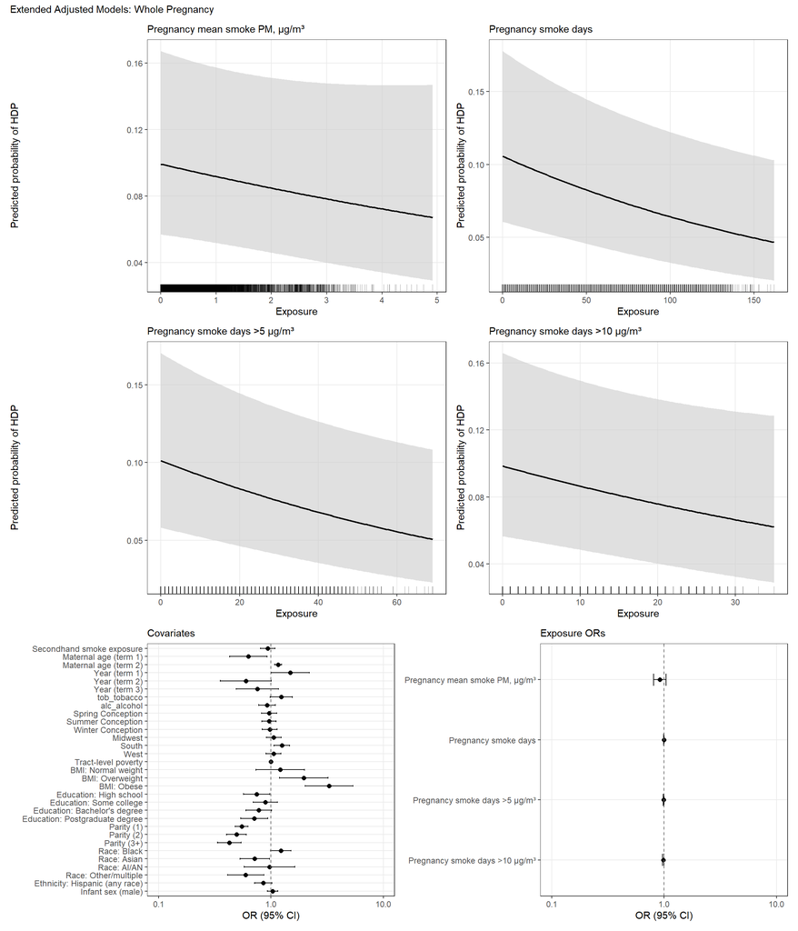

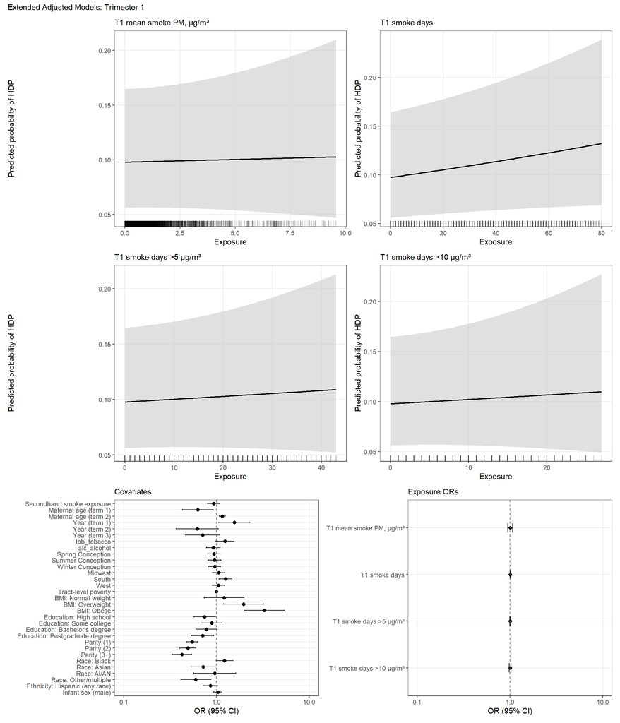

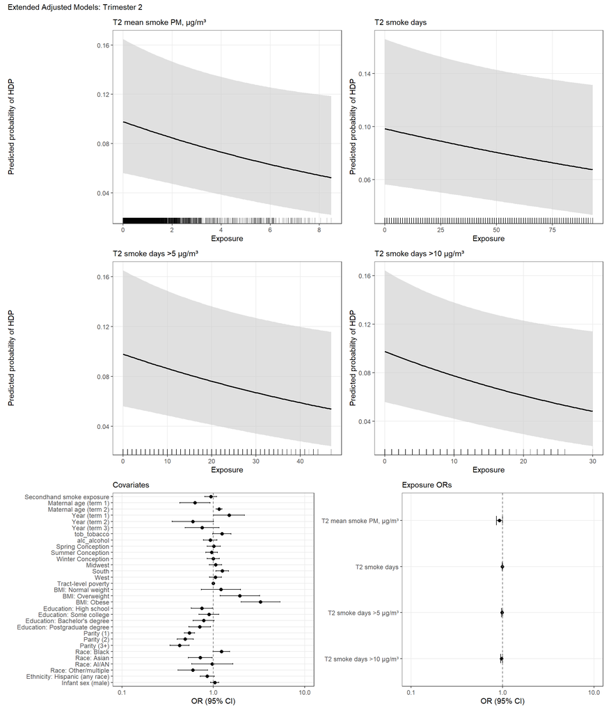

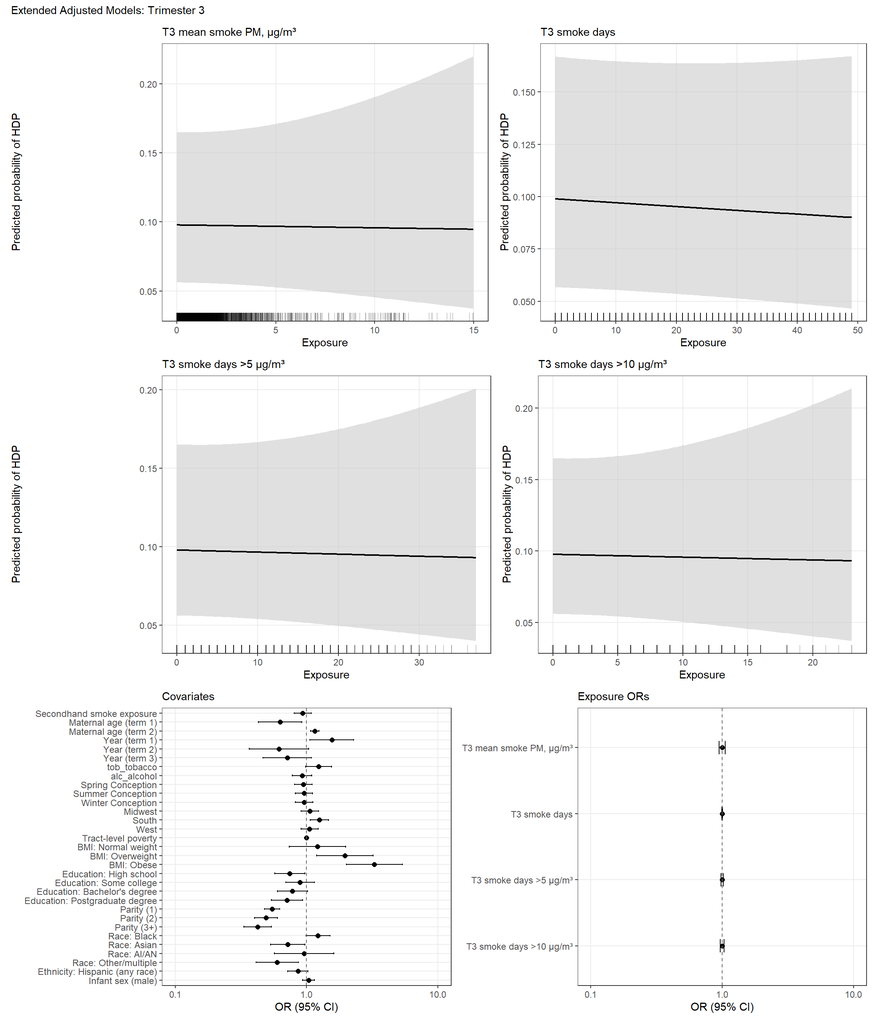